# Unit 9 Homework

Dana Geislinger

March 11, 2018

### **1.** Harry Potter Cast

IMDb provides a list of all credited cast members in the film **Harry Potter and the Deathly Hallows: Part 2**: http://www.imdb.com/title/tt1201607/fullcredits?ref_=tt_ql_1. This list will be parsed and cleaned using R to present the dataset in a table of actor first/last names and corresponding characer names.

**1a/b:** The table will first be scraped from the webpage and saved in an R *data.frame* object.

```r
# The library 'rvest' will be utilized to parse data from the webpage
require('rvest')
# Extract cast_list table from html parsed from webpage
#   Parse table saved as data.frame 'hp.df'
#   'css_selector' found in Google Chrome's 'Inspect' pane on webpage
hp.url = 'http://www.imdb.com/title/tt1201607/fullcredits?ref_=tt_ql_1'
hp.css_selector = '#fullcredits_content > table.cast_list'
hp.html = read_html(hp.url)
hp.raw_table = html_nodes(hp.html, hp.css_selector)
hp.df = data.frame(html_table(hp.raw_table))

# Verify structure of data.frame object
str(hp.df)
```

```
## 'data.frame':    151 obs. of  4 variables:
##  $ X1: chr  "" "" "" "" ...
##  $ X2: chr  "" "Ralph Fiennes" "Michael Gambon" "Alan Rickman" ...
##  $ X3: chr  "" "..." "..." "..." ...
##  $ X4: chr  "" "Lord Voldemort" "Professor Albus Dumbledore" "Professor Severus Snape" ...
```

**1c:** The raw data parsed from the website is not tidy. The imported data frame *hp.df* will be cleaned in R.

```r
# Remove unnecessary columns and rows and define meaningful column names
#   Remove 2 extraneous columns (blank and only containing '...')
#   Remove rows with blank actor names or named 'Rest of cast listed alphebetically:'
hp.df = subset(hp.df, X2 != '' & X2 != 'Rest of cast listed alphabetically:', select=c(X2, X4))
names(hp.df) = c('Actor_Name', 'Character_Name')

# Remove space and newline characters between Character names that span multiple table rows
hp.df$Character_Name = gsub('\\n', '', hp.df$Character_Name)
hp.df$Character_Name = sub('[[:space:]]{2,}', ' ', hp.df$Character_Name)

# Make sure Warwick Davis is credited correctly
subset(hp.df, Actor_Name == "Warwick Davis")
```

```
##       Actor_Name                       Character_Name
## 11 Warwick Davis Griphook / Professor Filius Flitwick
```

**1d/e:** The table on IMDb contains full actor and character names. First/middle and last actor names will be split into separate columns.

```r
# The 'extract' function from tidyr will be used to split split the 'Actor_Name' column
require('tidyr')
# Use regular expressions to split actor names and redefine columns in 'hp.df'
hp.df = extract(data=hp.df,
                col=Actor_Name,
                into=c("First_Name", "Last_Name"),
                regex='(^.+) (.+?$)'
                )

# Print Bob Yves Van Hellenberg Hubar's row to make sure middle names were split correctly
subset(hp.df, First_Name == 'Bob Yves Van Hellenberg')
```

```
##                 First_Name Last_Name Character_Name
## 82 Bob Yves Van Hellenberg     Hubar    Death Eater
```

```r
# Print the first 10 rows of the final dataset
head(hp.df, 10)
```

```
##    First_Name Last_Name                       Character_Name
## 2       Ralph   Fiennes                       Lord Voldemort
## 3     Michael    Gambon           Professor Albus Dumbledore
## 4        Alan   Rickman              Professor Severus Snape
## 5      Daniel Radcliffe                         Harry Potter
## 6      Rupert     Grint                          Ron Weasley
## 7        Emma    Watson                     Hermione Granger
## 8      Evanna     Lynch                        Luna Lovegood
## 9    Domhnall   Gleeson                         Bill Weasley
## 10   Clémence     Poésy                       Fleur Delacour
## 11    Warwick     Davis Griphook / Professor Filius Flitwick
```

### **2.** SportsBall

Current season statistics for the San Antonio Spurs is available from ESPN: http://www.espn.com/nba/team/stats/_/name/sa/san-antonio-spurs. This data will be parsed to acquire data on current season shooting statistics. Data will be downloaded, cleaned, and presented in R.

**2a/b:** The table will first be scraped from the webpage and saved in an R *data.frame* object.

```r
# Extract Shooting Statistics table from html parsed from webpage
#   Parse table saved as data.frame 'spurs.df'
#   'css_selector' found in Google Chrome's 'Inspect' pane on webpage
spurs.url = 'http://www.espn.com/nba/team/stats/_/name/sa/san-antonio-spurs'
spurs.css_selector = '#my-players-table > div.mod-container.mod-table > div:nth-child(3) > table'
spurs.html = read_html(spurs.url)
spurs.raw_table = html_nodes(spurs.html, spurs.css_selector)
spurs.df = data.frame(html_table(spurs.raw_table))

# Verify structure of raw data set
str(spurs.df)
```

```
## 'data.frame':    20 obs. of  15 variables:
##  $ X1 : chr  "SHOOTING STATISTICS" "PLAYER" "LaMarcus Aldridge, PF" "Kawhi Leonard, SF" ...
##  $ X2 : chr  "SHOOTING STATISTICS" "FGM" "8.7" "5.8" ...
##  $ X3 : chr  "SHOOTING STATISTICS" "FGA" "17.5" "12.3" ...
##  $ X4 : chr  "SHOOTING STATISTICS" "FG%" ".498" ".468" ...
##  $ X5 : chr  "SHOOTING STATISTICS" "3PM" "0.4" "1.2" ...
##  $ X6 : chr  "SHOOTING STATISTICS" "3PA" "1.3" "3.9" ...
##  $ X7 : chr  "SHOOTING STATISTICS" "3P%" ".313" ".314" ...
##  $ X8 : chr  "SHOOTING STATISTICS" "FTM" "4.4" "3.4" ...
##  $ X9 : chr  "SHOOTING STATISTICS" "FTA" "5.2" "4.2" ...
##  $ X10: chr  "SHOOTING STATISTICS" "FT%" "0.83" "0.82" ...
##  $ X11: chr  "SHOOTING STATISTICS" "2PM" "8.3" "4.6" ...
##  $ X12: chr  "SHOOTING STATISTICS" "2PA" "16.2" "8.4" ...
##  $ X13: chr  "SHOOTING STATISTICS" "2P%" ".513" ".539" ...
##  $ X14: chr  "SHOOTING STATISTICS" "PPS" "1.268" "1.315" ...
##  $ X15: chr  "SHOOTING STATISTICS" "AFG%" "0.51" "0.52" ...
```

**2c:** Data parsed from ESPN is very messy. Data will be cleaned in R by removing extraneous rows/columns, assigning meaningful column names, creating distinct player name/position columns, and converting improperly formatted data.

```r
# Correctly assign column titles
#   Correct column titles were parsed from the webpage, but were erroneously stored in row 2 instead of as column titles
names(spurs.df) = spurs.df[2, ]

# Remove first 2 rows (incorrectly placed titles) and last row (Totals, not necessary for this analysis)
spurs.df = spurs.df[3:19, ]

# Split 'PLAYER' column into 'Name' and 'Position' columns
spurs.df = extract(data=spurs.df,
                   col=PLAYER,
                   into=c('Name', 'Position'),
                   regex='(^.+), (.+$)'
                   )

# Print data types for each variable
sapply(spurs.df, class)
```

```
##        Name    Position         FGM         FGA         FG%         3PM
## "character" "character" "character" "character" "character" "character"
##         3PA         3P%         FTM         FTA         FT%         2PM
## "character" "character" "character" "character" "character" "character"
##         2PA         2P%         PPS        AFG%
## "character" "character" "character" "character"
```

```r
# Convert statistical variables to numeric
spurs.df[, 3:16] = sapply(spurs.df[, 3:16], as.numeric)

# Print data types for dataset variables to confirm changes
sapply(spurs.df, class)
```

```
##        Name    Position         FGM         FGA         FG%         3PM
## "character" "character"   "numeric"   "numeric"   "numeric"   "numeric"
##         3PA         3P%         FTM         FTA         FT%         2PM
##   "numeric"   "numeric"   "numeric"   "numeric"   "numeric"   "numeric"
##         2PA         2P%         PPS        AFG%
##   "numeric"   "numeric"   "numeric"   "numeric"
```

```r
# Print structure of dataset to verify changes
str(spurs.df)
```

```
## 'data.frame':    17 obs. of  16 variables:
##  $ Name    : chr  "LaMarcus Aldridge" "Kawhi Leonard" "Rudy Gay" "Pau Gasol" ...
##  $ Position: chr  "PF" "SF" "SF" "C" ...
##  $ FGM     : num  8.7 5.8 4.3 3.9 3.3 3.2 3.2 3.8 3.2 3.2 ...
##  $ FGA     : num  17.5 12.3 9.1 8.6 8 7.3 8 7.8 6.2 7.2 ...
##  $ FG%     : num  0.498 0.468 0.473 0.459 0.417 0.439 0.407 0.485 0.518 0.44 ...
##  $ 3PM     : num  0.4 1.2 0.7 0.7 1.8 1 1.7 0.1 0.2 0.1 ...
##  $ 3PA     : num  1.3 3.9 2 1.7 4.8 3.1 4.5 0.7 0.7 0.4 ...
##  $ 3P%     : num  0.313 0.314 0.325 0.387 0.381 0.327 0.382 0.192 0.275 0.261 ...
##  $ FTM     : num  4.4 3.4 2 2.1 1.2 1.5 0.6 1 1.6 1.1 ...
##  $ FTA     : num  5.2 4.2 2.6 2.8 1.3 1.8 0.8 1.5 2.1 1.6 ...
##  $ FT%     : num  0.83 0.82 0.78 0.76 0.88 0.86 0.78 0.69 0.73 0.73 ...
##  $ 2PM     : num  8.3 4.6 3.6 3.2 1.5 2.2 1.5 3.7 3 3.1 ...
##  $ 2PA     : num  16.2 8.4 7.1 6.9 3.2 4.2 3.5 7.1 5.5 6.8 ...
##  $ 2P%     : num  0.513 0.539 0.515 0.477 0.473 0.518 0.439 0.513 0.548 0.45 ...
##  $ PPS     : num  1.27 1.31 1.24 1.24 1.21 ...
##  $ AFG%    : num  0.51 0.52 0.51 0.5 0.53 0.51 0.51 0.49 0.53 0.45 ...
```

**2d:** The potential relationship between player position and field goal percentage per game is of interest. To help illustrate this relationship, a bar graph will be printed using R that prints player field goal percentage color coded by their position.

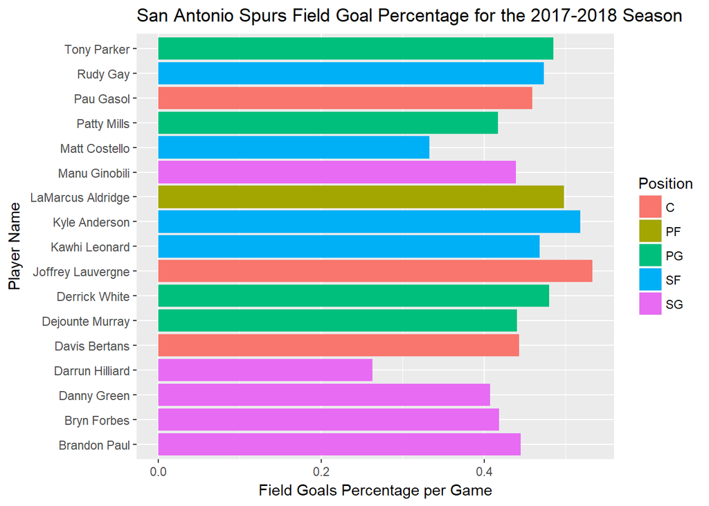

```r
# The ggplot2 library will be used to plot data
require('ggplot2')
# Create ggplot2 horizontal bar chart object of FG% per player color-coded by position
spurs.plot = ggplot(data=spurs.df,
                    aes(x=Name,
                        y=`FG%`,
                        fill=Position)
                    ) + geom_col() + coord_flip()

# Plot barplot with descriptive x and y labels and graph title
spurs.plot + labs(x='Player Name',
                  y='Field Goals Percentage per Game',
                  title='San Antonio Spurs Field Goal Percentage for the 2017-2018 Season'
                  )
```